# Informe tecnico - Migracion neta internacional

Nabel Baghach

23 agosto 2025

# 1 Introduccion

Este informe presenta un an?lisis reproducible de la migraci?n neta internacional por pa?s y a?o a partir de datos abiertos. Se documenta la estructura del proyecto, los objetivos, la metodolog?a y un primer resumen de resultados.

Comprobacion de carga de datos

| archivo_usado | filas | columnas | anio_min | anio_max |
| --- | --- | --- | --- | --- |
| C:/Users/nabee/Desktop/MASTER BEHAVIOURAL DATA SCIENCE/MODULO VIII/RETO II/Reto-II/Datos/Base_de_datos_depurada/migracion_neta_limpio.csv | 1624 | 21 | 1990 | 2019 |

```
##  [1] "geo"                    "year"                   "immigrant_stock_value"
##  [4] "g77_and_oecd_countries" "income_groups"          "is_country"
##  [7] "iso3166_1_alpha2"       "unicode_region_subtag"  "iso3166_1_alpha3"
## [10] "iso3166_1_numeric"      "landlocked"             "latitude"
## [13] "longitude"              "main_religion_2008"     "name"
## [16] "un_state"               "world_4region"          "world_6region"
## [19] "country_name"           "emigrant_stock_value"   "net_migration"
```

# 2 Objetivos del proyecto

### 2.0.1 Objetivo principal

Analizar la evolucion y las diferencias en la migracion neta internacional por pais y año, a partir de datos abiertos procedentes de Gapminder/UN DESA, con el fin de identificar patrones regionales y socioeconomicos relevantes en los flujos migratorios y contribuir a una mejor comprension de las dinamicas poblacionales a nivel global.

### 2.0.2 Objetivos especificos

- Construir una base de datos reproducible que integre los indicadores de inmigraci?n y emigraci?n, generando el indicador de migraci?n neta por pa?s y a?o.
- Realizar un an?lisis descriptivo multivariante de la migraci?n neta, incorporando dimensiones geogr?ficas y socioecon?micas (por ejemplo, regiones mundiales y niveles de ingresos).
- Implementar visualizaciones din?micas que permitan explorar de manera interactiva la evoluci?n temporal y regional de la migraci?n neta.
- Elaborar un informe t?cnico reproducible que resuma los principales hallazgos y tendencias, integrando texto y resultados generados con R.
- Dise?ar una presentaci?n acad?mica reproducible que comunique de forma clara y sint?tica los resultados obtenidos, incluyendo tablas, gr?ficos y explicaciones fundamentadas.

**Cobertura temporal:** 1990–2019.  
**Número de países:** 232.  
**Migración neta global en 2019:** 11M.

Top 10 por magnitud de migración neta en 2019

| País | Inmigrantes | Emigrantes | Migración neta |
| --- | --- | --- | --- |
| United States | 50661149 | 3167072 | 47494077 |
| Saudi Arabia | 13122338 | 296254 | 12826084 |
| India | 5154737 | 17510931 | -12356194 |
| Mexico | 1060707 | 11796178 | -10735471 |
| China | 1030871 | 10732281 | -9701410 |
| Germany | 13132146 | 4014203 | 9117943 |
| United Arab Emirates | 8587256 | 154404 | 8432852 |
| Syria | 867848 | 8225499 | -7357651 |
| Australia | 7549270 | 577255 | 6972015 |
| Canada | 7960657 | 1323087 | 6637570 |

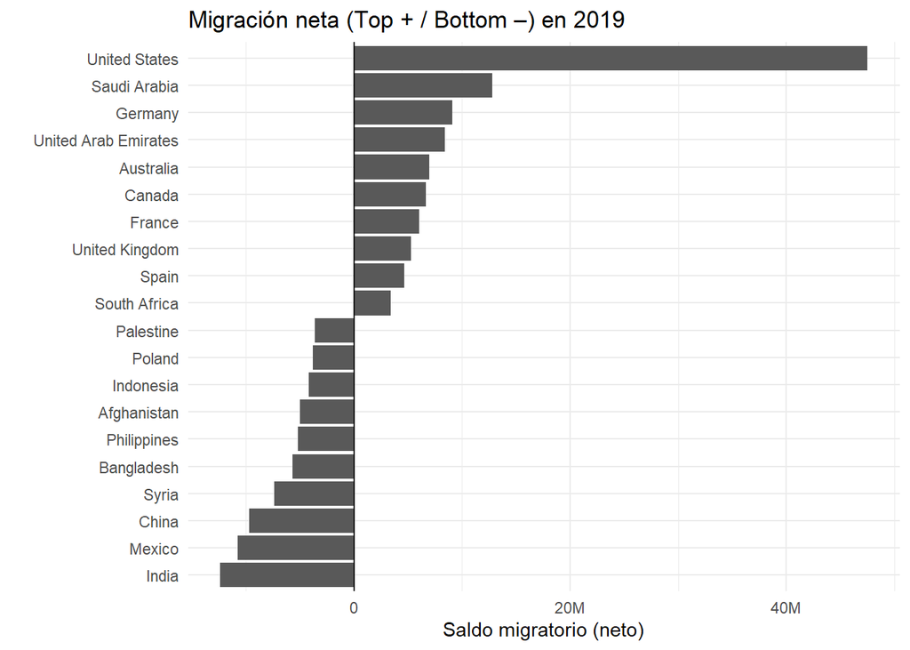

**Lectura.** Se observan países con saldos fuertemente positivos (atracción) y negativos (expulsión) en 2019, lo que complementa la tabla y ayuda a visualizar la **asimetría**.

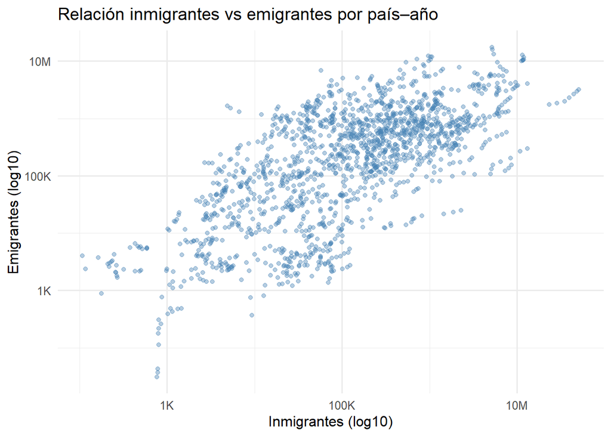

**Lectura.** La relación entre inmigrantes y emigrantes sigue una tendencia positiva: los países con grandes volúmenes de inmigración suelen presentar también cifras elevadas de emigración. El uso de escala log–log permite comparar países muy diferentes en tamaño poblacional.

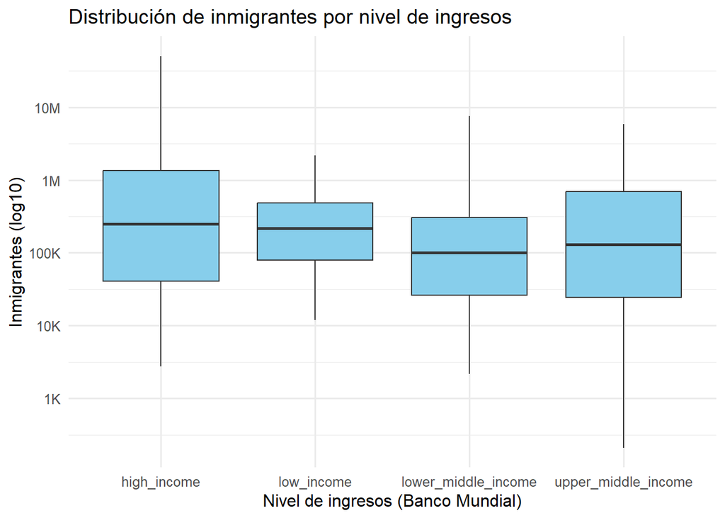

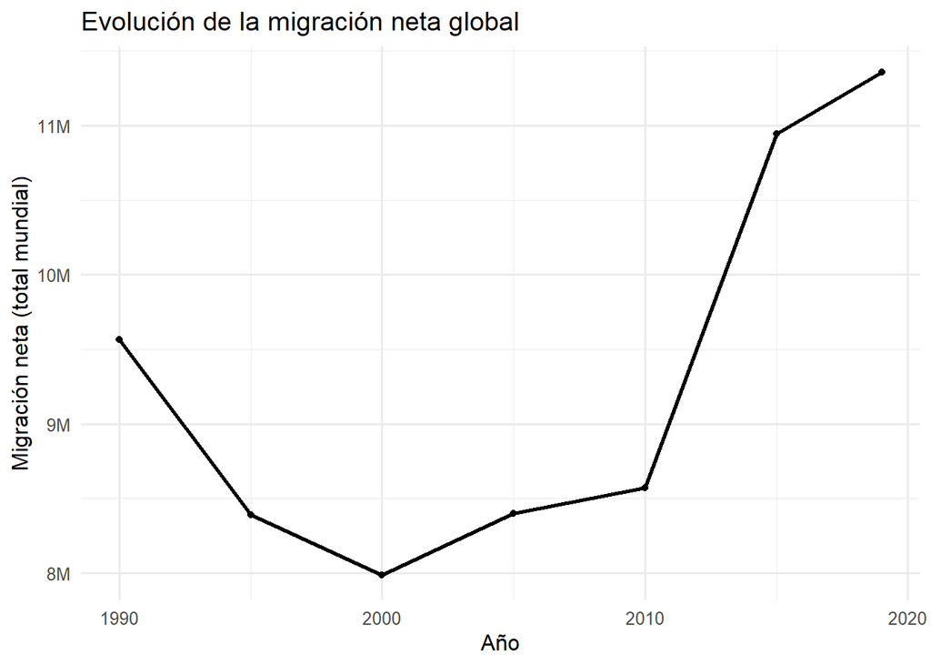

**Lectura.** La migración neta global alcanzó 11M en 2019. Las variaciones interanuales podrían vincularse con factores económicos, políticos o sanitarios.

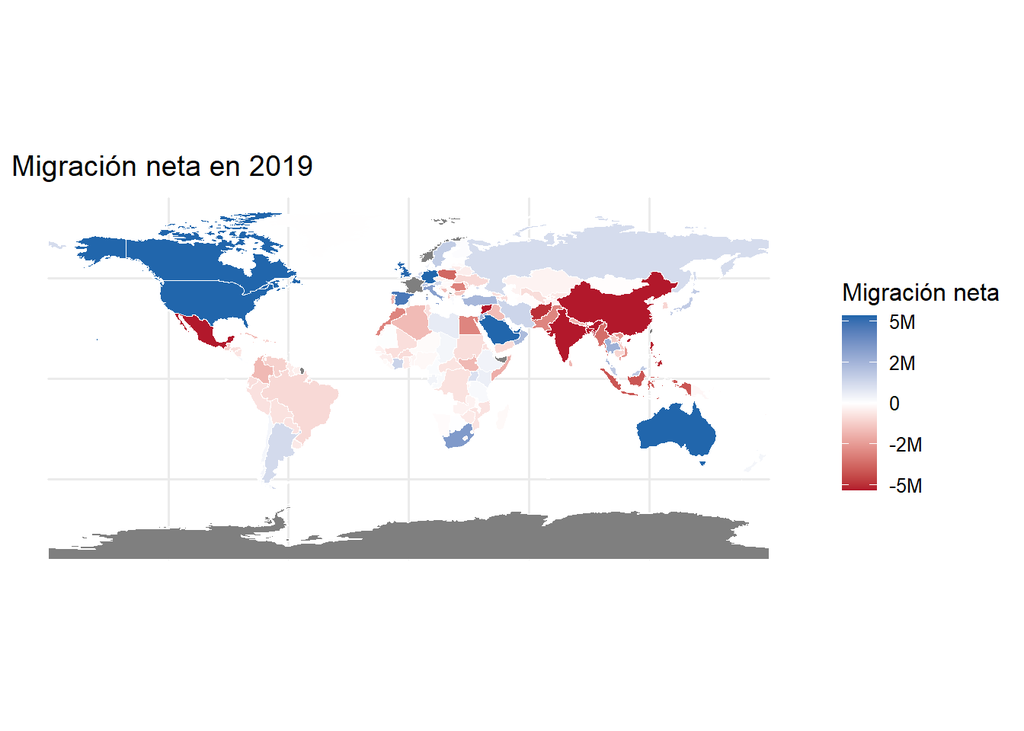

**Lectura.** El mapa muestra la distribución espacial de la migración neta en 2019. Los países con saldos positivos se concentran en regiones de altos ingresos y algunos países del Golfo, mientras que las pérdidas netas más pronunciadas corresponden a economías en desarrollo y zonas de conflicto.